# RR_Task_8_report

## Suits viewership numbers analysis

Author: Kacper Sokolowski  
Date: 21/04/2024

[figure not shown]

**Suits (TV Series)**

*Suits* is an American legal drama television series created and written by Aaron Korsh. The show premiered on June 23, 2011, on the cable network USA, and concluded on September 25, 2019, after nine seasons and 134 episodes.

**Overview**

The series revolves around Harvey Specter (Gabriel Macht), a senior partner at a top law firm in Manhattan, and his recently hired associate attorney Mike Ross (Patrick J. Adams). What sets Mike apart is his eidetic memory and his genuine law expertise despite never attending law school. The show focuses on Harvey and Mike managing to close cases while maintaining Mike's secret.

**Themes and Setting**

*Suits* is set at a fictional law firm in New York City, and later in the series, the firm undergoes several name changes due to shifts in leadership and mergers. The show features a slick, polished aesthetic and fast-paced dialogues. It delves into various themes such as mentorship, the cost of success, and the moral ambiguity of high-stakes law practice.

**Reception**

The show has been well-received for its sharp wit, characters, and performances. It also gained recognition for its stylish wardrobe, particularly the impeccable suits worn by the characters, contributing to the show's name and allure.

### Required libraries

```python
import requests
from bs4 import BeautifulSoup
import pandas as pd
import matplotlib.pyplot as plt
from IPython.display import Markdown, display
```

### Collect viewership data

```python
url = 'https://en.wikipedia.org/wiki/List_of_Suits_episodes'

response = requests.get(url)

soup = BeautifulSoup(response.text, 'html.parser')

tables = soup.findAll('table', {'class': 'wikitable plainrowheaders wikiepisodetable'})

viewership_data = []

season = 0
for table in tables[:-1]:
    rows = table.find_all('tr')
    for row in rows[1:]:
        cols = row.find_all('td')
        if cols:
            episode = cols[0].text.strip()
            viewers = cols[-1].text.strip()

            viewers = float(viewers[:4])
            episode = int(''.join(filter(str.isdigit, episode)))

            if episode == 1:
                season += 1

            viewership_data.append((season, episode, viewers))

df = pd.DataFrame(viewership_data, columns=['Season', 'Episode', 'Viewers'])
```

```python
df.head(5)
```

|  | Season | Episode | Viewers |
| --- | --- | --- | --- |
| 0 | 1 | 1 | 4.64 |
| 1 | 1 | 2 | 3.89 |
| 2 | 1 | 3 | 4.53 |
| 3 | 1 | 4 | 4.38 |
| 4 | 1 | 5 | 4.38 |

```python
df.tail(5)
```

|  | Season | Episode | Viewers |
| --- | --- | --- | --- |
| 129 | 9 | 6 | 1.05 |
| 130 | 9 | 7 | 1.07 |
| 131 | 9 | 8 | 0.97 |
| 132 | 9 | 9 | 0.96 |
| 133 | 9 | 10 | 0.86 |

### Basic viewership statistics (numbers in millions of viewers)

```python
print(df['Viewers'].describe()[1:])
```

```
mean    2.180224
std     1.065726
min     0.690000
25%     1.272500
50%     1.870000
75%     2.862500
max     4.640000
Name: Viewers, dtype: float64
```

### Viewership Over Time

#### Episode level

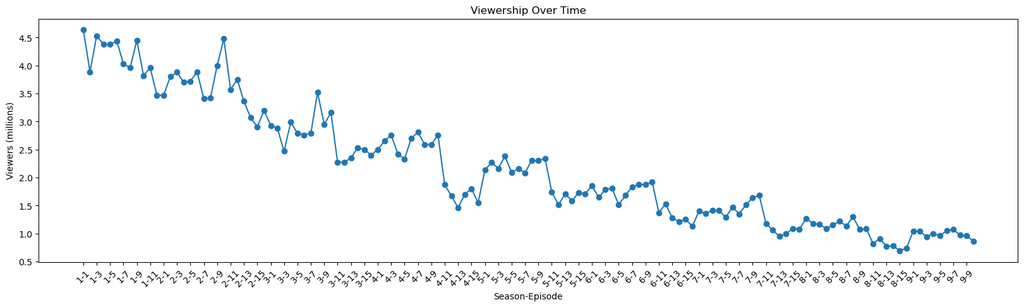

```python
df['Episode_ID'] = df['Season'].astype(str) + '-' + df['Episode'].astype(str)
ticks_to_use = df['Episode_ID'][::2]

plt.figure(figsize=(20, 5))
plt.plot(df['Episode_ID'], df['Viewers'], marker='o')
plt.title('Viewership Over Time')
plt.xlabel('Season-Episode')
plt.ylabel('Viewers (millions)')
plt.xticks(ticks_to_use, rotation=45)
plt.show()
```

#### Season level

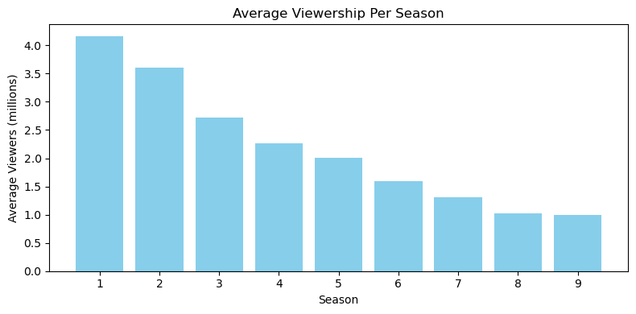

```python
df_seasonal = df.groupby('Season')['Viewers'].mean().reset_index()
plt.figure(figsize=(8, 4))
plt.bar(df_seasonal['Season'].astype(str), df_seasonal['Viewers'], color='skyblue')
plt.title('Average Viewership Per Season')
plt.xlabel('Season')
plt.ylabel('Average Viewers (millions)')
plt.xticks(rotation=0)
plt.tight_layout()
plt.show()
```

### Episode-to-Episode Changes in Viewership

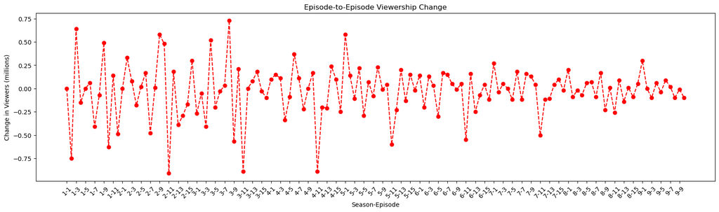

```python
df['Viewership_Change'] = df['Viewers'].diff().fillna(0)
plt.figure(figsize=(20, 5))
plt.plot(df['Episode_ID'], df['Viewership_Change'], marker='o', linestyle='--', color='red')
plt.title('Episode-to-Episode Viewership Change')
plt.xlabel('Season-Episode')
plt.ylabel('Change in Viewers (millions)')
plt.xticks(ticks_to_use, rotation=45)
plt.show()
```

### General Comment

**Viewership Over Time**

The first graph depicts a comprehensive trajectory of 'Suits' viewership across all nine seasons on an episode-by-episode basis. It unveils that the series premiered with robust ratings, garnering approximately 4.64 million viewers for the first episode. This high level of initial engagement indicates a strong audience interest at the outset of the series.

As the show progressed, a decline in viewership became evident, demonstrating a typical pattern for long-running TV series where audience numbers often diminish over time. Notably, the drop from the premiere episode of the first season to the finale of the last season underscores this trend, with the viewership dwindling to just 0.86 million.

**Average Viewership Per Season**

The bar chart showcasing average viewership per season further substantiates this downward trend. Season 1 enjoyed the highest average viewership, indicating that the show had a compelling start. Thereafter, each subsequent season experienced a decrease in average viewership, with Season 9 registering the lowest, reflecting a gradual viewer attrition as the series neared its conclusion.

**Episode-to-Episode Viewership Change**

The episodic viewership change graph reveals the volatility in viewership between individual episodes. While some episodes experienced a surge in viewers, others saw a decline. This fluctuation might be attributed to several factors, including episode story quality, cliffhangers, and seasonal events affecting television viewing habits.

```python
total_decline = df.Viewers[0] - df.Viewers[len(df)-1]
total_decline = int(total_decline*10**6)
display(Markdown(f"$\\text{{Total decline in viewership: }} {total_decline} \\text{{ million}}$"))
```

[output not shown]